# Natural Disasters

Darin Nguyen & Rohith Sarma

11/15/2022

### MOST RECENT NATURAL DISASTERS FROM 1955-2016 PER STATE/TERRITORY

```
## # A tibble: 59 × 2
##    State max_date
##    <chr> <chr>
##  1 AK    12/22/2011
##  2 AL    12/31/2009
##  3 AR    12/31/1987
##  4 AS    12/13/1991
##  5 AZ    12/21/2010
##  6 CA    12/29/1956
##  7 CO    11/12/2003
##  8 CT    12/17/1992
##  9 DC    12/05/2012
## 10 DE    11/16/2012
## 11 FL    12/17/1962
## 12 FM    12/19/2003
```

[output cut: 47 more lines]

This table shows the most recent natural disasters in each of the 50 United States and territories ranging from the years 1955 to 2016. This data was sorted from the states and territories abbreviations in alphabetical order. This helps emphasize which states have been most vulnerable to natural disasters over the 61 year period.

### MOST DEATHS FROM A NATURAL DISASTER SINCE 1980

The highest number of deaths from a natural disaster since 1980 was `2981`. `2981` people died during Hurricane Maria in September of 2017. Hurricane Maria was a category 5 hurricane that affected most of the Caribbean including Dominica, Saint Croix, and Puerto Rico. It is estimated that Hurricane Maria costed over $90 Billion in monetary losses.

## Natural Disasters in the United States of America

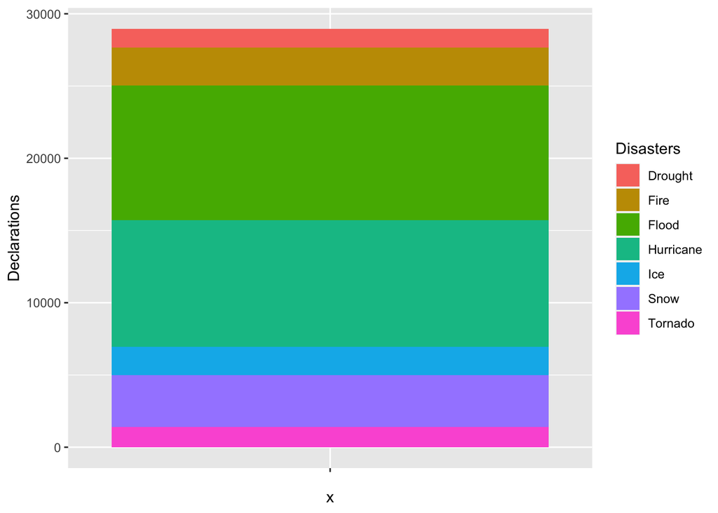

This length encoding chart shows the leading seven types of declared disasters in the United States of America since 1953. It can be seen from the chart, that Hurricanes and Floods are the most prominent disasters since 1953 with a declaration amount of 8764, and 9317, respectively. The remaining five types of declared disasters include droughts, fires, ice, snow, and tornadoes. This plot is useful because it visually shows the gap there is in the amount of times certain disasters happen.

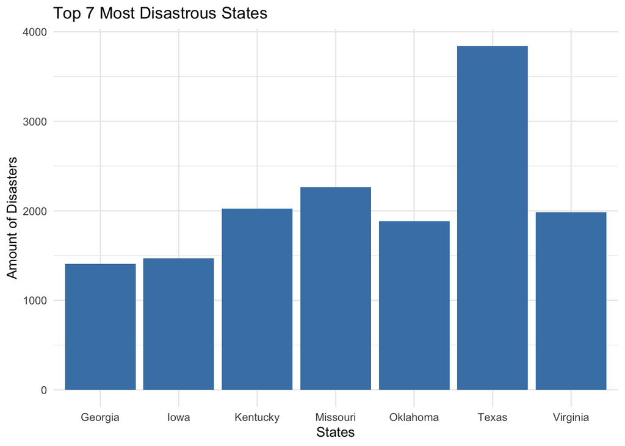

This bar graph depicts the top seven states where natural disasters have occurred most since 1953. It can be seen that Texas is clearly the leading state when it comes to natural disaster occurrences since then. Missouri, Kentucky, Virginia, Oklahoma, Iowa, and Georgia are the next 6 states in order where natural disasters have occurred the most.